# Análisis Exploratorio de Datos (EDA) - Proyecto de Transporte

### Objetivos del Proyecto y Definición de Variables

El objetivo principal de este proyecto es desarrollar un modelo basado en **Máquinas de Vectores de Soporte (SVM)** para predecir el **modo de transporte** utilizado por un individuo en función de los datos recopilados por sensores de dispositivos móviles. Se busca analizar cómo las diferentes señales captadas por el acelerómetro, giróscopo, barómetro, GPS y magnetómetro pueden ser utilizadas para inferir con precisión el medio de transporte en uso.

Para lograr esto, se cuenta con un conjunto de datos que incluye:

1. **Registro Temporal**
   - Cada observación está asociada a un instante de tiempo específico.
2. **Datos de Movimiento y Orientación**
   - **Acelerómetro**: Componentes X, Y, Z del vector aceleración.
   - **Giróscopo**: Velocidad angular en los ejes X, Y, Z y su derivada.
   - **Matriz de Rotación y Cuaterniones**: Representan la orientación tridimensional del dispositivo.
3. **Datos de Ubicación y Contexto**
   - **GPS**: Coordenadas de latitud y longitud, velocidad, altitud y rumbo.
   - **Presión Atmosférica**: Valores obtenidos del barómetro, junto con la altitud relativa.
   - **Campo Magnético Terrestre**: Medición en los ejes X, Y, Z.
4. **Variables Categóricas**
   - **Modo de Transporte**: La categoría que se busca predecir (caminar, bicicleta, automóvil, etc.).
   - **Nivel de Confianza**: Un indicador de la precisión estimada para la clasificación del transporte en los datos originales.

### Alcance del Análisis

El análisis exploratorio de datos (EDA) busca comprender la estructura del dataset, identificar patrones y evaluar la calidad de los datos antes de proceder con el modelado. Se incluyen tareas como:

- **Identificación y tratamiento de outliers univariantes y multivariantes.**
- **Evaluación de la normalidad y distribución de las variables.**
- **Exploración de la correlación entre variables para determinar redundancias o relaciones clave.**
- **Selección de variables relevantes para el modelo.**

# **1. Carga de librerías**

```r
# Lista de paquetes necesarios
necessary_packages <- c("dplyr", "ggplot2", "DataExplorer", "naniar",
                        "moments", "psych", "caret", "lubridate", "chemometrics")

# Instalar paquetes que no están instalados
new_packages <- necessary_packages[!(necessary_packages %in% installed.packages()[, "Package"])]
if (length(new_packages) > 0) {
  install.packages(new_packages)
}

# Cargar todos los paquetes
lapply(necessary_packages, library, character.only = TRUE)
```

[output not shown]

```r
# Cargar las librerías
library(lubridate)
library(dplyr)
library(ggplot2)
library(naniar)
library(moments)
library(psych)
library(caret)
library(reshape2)
library(geosphere)
library(zoo)
# Cargar librerías necesarias
library(ggplot2)
library(gridExtra) # Para organizar múltiples gráficos
library(ggpubr)    # Para Q-Q plots
library(chemometrics)
library(mice)
library(tidyr)
library(tidyverse)
library(cowplot)
```

# 2. Cargar el dataset

```r
# Ruta del archivo CSV (modificar según tu sistema)
ruta_dataset <- "250Hz-v5_20240204_110747_60s-coche-urbano.csv"

data <- read.csv(ruta_dataset)

# Resumen del dataset
cat("### Información General del Dataset")
```

```
### Información General del Dataset
```

```r
dim(data) # Dimensiones del dataset
```

```
[1] 7033   44
```

```r
str(data) # Estructura del dataset
```

```
'data.frame':   7033 obs. of  44 variables:
 $ Timestamp               : chr  "04-Feb-2024 11:07:47.524" "04-Feb-2024 11:07:47.530" "04-Feb-2024 11:07:47.534" "04-Feb-2024 11:07:47.538" ...
 $ accelX.g.               : num  -0.0263 -0.0159 -0.0159 -0.0159 -0.0233 -0.0233 -0.0312 -0.0312 -0.0231 -0.0231 ...
 $ accelY.g.               : num  0.146 0.15 0.15 0.15 0.145 ...
 $ accelZ.g.               : num  -0.98 -0.981 -0.981 -0.981 -0.981 ...
 $ accelUserX.g.           : num  -0.0097 0.0007 0.0007 0.0007 -0.0067 -0.0067 -0.0146 -0.0146 -0.0065 -0.0066 ...
 $ accelUserY.g.           : num  -0.0145 -0.0102 -0.0102 -0.0102 -0.0147 -0.0147 -0.0204 -0.0204 -0.0186 -0.0186 ...
 $ accelUserZ.g.           : num  0.0071 0.0063 0.0063 0.0063 0.0056 0.0056 0.0057 0.0057 0.0051 0.0051 ...
 $ gyroX.rad.s.            : num  -0.0407 -0.0334 -0.0343 -0.0343 -0.0343 -0.0347 -0.0347 -0.0399 -0.0399 -0.0358 ...
 $ gyroY.rad.s.            : num  0.0103 0.0093 0.0037 0.0037 0.0037 0.0091 0.0091 0.0125 0.0125 0.0098 ...
 $ gyroZ.rad.s.            : num  -0.0095 -0.0089 -0.0084 -0.0084 -0.0084 -0.0064 -0.0064 -0.0062 -0.0062 -0.0057 ...
 $ Roll.rads.              : num  -0.0168 -0.0168 -0.0168 -0.0168 -0.0168 -0.0168 -0.0168 -0.0168 -0.0168 -0.0167 ...
 $ Pitch.rads.             : num  -0.161 -0.161 -0.161 -0.161 -0.161 ...
 $ Yaw.rads.               : num  -2.01 -2.01 -2.01 -2.01 -2.01 ...
 $ m11                     : num  -0.418 -0.418 -0.418 -0.418 -0.418 ...
```

[output cut: 30 more lines]

```r
summary(data) # Resumen estadístico básico
```

```
  Timestamp           accelX.g.           accelY.g.          accelZ.g.       accelUserX.g.      accelUserY.g.       accelUserZ.g.       gyroX.rad.s.       gyroY.rad.s.        gyroZ.rad.s.        Roll.rads.
 Length:7033        Min.   :-0.208200   Min.   :-0.16410   Min.   :-1.2046   Min.   :-0.22400   Min.   :-0.170800   Min.   :-0.20490   Min.   :-0.41190   Min.   :-0.233100   Min.   :-0.05660   Min.   :-0.02590
 Class :character   1st Qu.:-0.021600   1st Qu.: 0.02740   1st Qu.:-1.0068   1st Qu.:-0.00830   1st Qu.:-0.030300   1st Qu.:-0.00950   1st Qu.:-0.05690   1st Qu.:-0.006900   1st Qu.:-0.00970   1st Qu.:-0.01590
 Mode  :character   Median :-0.013000   Median : 0.05980   Median :-0.9860   Median :-0.00130   Median :-0.008300   Median : 0.01060   Median :-0.03040   Median : 0.003300   Median :-0.00810   Median :-0.01490
                    Mean   : 0.004222   Mean   : 0.04603   Mean   :-0.9864   Mean   : 0.00803   Mean   :-0.005504   Mean   : 0.01136   Mean   :-0.03226   Mean   : 0.003344   Mean   : 0.01354   Mean   :-0.00387
                    3rd Qu.: 0.018400   3rd Qu.: 0.06850   3rd Qu.:-0.9661   3rd Qu.: 0.01210   3rd Qu.: 0.015200   3rd Qu.: 0.03170   3rd Qu.:-0.00780   3rd Qu.: 0.015700   3rd Qu.:-0.00530   3rd Qu.: 0.00980
                    Max.   : 0.205500   Max.   : 0.20270   Max.   :-0.6396   Max.   : 0.20490   Max.   : 0.178400   Max.   : 0.35930   Max.   : 0.29060   Max.   : 0.184900   Max.   : 0.36750   Max.   : 0.03290
  Pitch.rads.         Yaw.rads.            m11               m12               m13                 m21              m22               m23                m31                m32                 m33
 Min.   :-0.16090   Min.   :-2.0465   Min.   :-0.4580   Min.   :-0.9997   Min.   :-0.032900   Min.   :0.4245   Min.   :-0.4580   Min.   :-0.16020   Min.   :-0.03130   Min.   :-0.053500   Min.   :0.9869
 1st Qu.:-0.07460   1st Qu.:-2.0028   1st Qu.:-0.4174   1st Qu.:-0.9086   1st Qu.:-0.009800   1st Qu.:0.4338   1st Qu.:-0.4172   1st Qu.:-0.07450   1st Qu.: 0.01690   1st Qu.:-0.018400   1st Qu.:0.9971
 Median :-0.04250   Median :-2.0020   Median :-0.4170   Median :-0.9083   Median : 0.014700   Median :0.8999   Median :-0.4156   Median :-0.04250   Median : 0.03180   Median :-0.012300   Median :0.9990
 Mean   :-0.05159   Mean   :-1.3642   Mean   : 0.1289   Mean   :-0.7253   Mean   : 0.003841   Mean   :0.7231   Mean   : 0.1291   Mean   :-0.05152   Mean   : 0.04854   Mean   :-0.003073   Mean   :0.9977
 3rd Qu.:-0.02150   3rd Qu.:-0.4490   3rd Qu.: 0.9008   3rd Qu.:-0.4342   3rd Qu.: 0.015900   3rd Qu.:0.9060   3rd Qu.: 0.9005   3rd Qu.:-0.02150   3rd Qu.: 0.07430   3rd Qu.: 0.019700   3rd Qu.:0.9996
 Max.   : 0.04020   Max.   :-0.4385   Max.   : 0.9053   Max.   :-0.4247   Max.   : 0.025900   Max.   :0.9997   Max.   : 0.9053   Max.   : 0.04020   Max.   : 0.15240   Max.   : 0.042800   Max.   :1.0000
       qX                 qY                 qZ                qW              Lat             Long         Speed.m.s.       TrueHeading        Alt.m.      HorizontalAccuracy.m. VerticalAccuracy.m.     Course
 Min.   :-0.05030   Min.   :-0.02060   Min.   :-0.8538   Min.   :0.5206   Min.   :41.39   Min.   :2.156   Min.   : 0.0000   Min.   :268.3   Min.   :32.22   Min.   : 6.000        Min.   :3           Min.   :  4.8
 1st Qu.:-0.02680   1st Qu.: 0.00690   1st Qu.:-0.8414   1st Qu.:0.5389   1st Qu.:41.39   1st Qu.:2.158   1st Qu.: 0.1441   1st Qu.:271.3   1st Qu.:32.33   1st Qu.: 8.000        1st Qu.:3           1st Qu.: 45.4
 Median :-0.01980   Median : 0.01590   Median :-0.8402   Median :0.5394   Median :41.39   Median :2.158   Median : 2.5935   Median :356.6   Median :32.33   Median : 8.000        Median :3           Median : 45.4
 Mean   :-0.01883   Mean   : 0.01834   Mean   :-0.5889   Mean   :0.7208   Mean   :41.39   Mean   :2.158   Mean   : 3.8939   Mean   :321.1   Mean   :32.92   Mean   : 8.342        Mean   :3           Mean   :153.0
 3rd Qu.:-0.00770   3rd Qu.: 0.02710   3rd Qu.:-0.2226   3rd Qu.:0.9748   3rd Qu.:41.39   3rd Qu.:2.158   3rd Qu.: 8.2253   3rd Qu.:356.6   3rd Qu.:33.46   3rd Qu.: 8.000        3rd Qu.:3           3rd Qu.:315.2
 Max.   : 0.00700   Max.   : 0.06350   Max.   :-0.2175   Max.   :0.9760   Max.   :41.39   Max.   :2.158   Max.   :11.2455   Max.   :358.6   Max.   :36.18   Max.   :12.000        Max.   :3           Max.   :315.5
 ActivityType       ActivityConfidence Pressure.kilopascals. RelativeAltitude.meters.    magX.µT.        magY.µT.        magZ.µT.       calMagX.µT.       calMagY.µT.     calMagZ.µT.
 Length:7033        Length:7033        Min.   :102.5         Min.   : 7.647           Min.   :164.1   Min.   :73.31   Min.   :-621.3   Min.   :-25.413   Min.   : 4.55   Min.   :-7.5339
 Class :character   Class :character   1st Qu.:102.5         1st Qu.: 9.158           1st Qu.:166.1   1st Qu.:79.74   1st Qu.:-617.1   1st Qu.:-23.229   1st Qu.:11.19   1st Qu.:-3.2925
 Mode  :character   Mode  :character   Median :102.6         Median : 9.306           Median :166.5   Median :80.75   Median :-614.5   Median :-22.918   Median :12.23   Median :-0.7563
                                       Mean   :102.5         Mean   :10.088           Mean   :180.0   Mean   :80.77   Mean   :-615.4   Mean   : -9.383   Mean   :12.24   Mean   :-1.6437
                                       3rd Qu.:102.6         3rd Qu.:11.003           3rd Qu.:199.6   3rd Qu.:81.05   3rd Qu.:-613.9   3rd Qu.: 10.218   3rd Qu.:12.51   3rd Qu.:-0.1249
                                       Max.   :102.6         Max.   :14.078           Max.   :201.7   Max.   :88.61   Max.   :-608.0   Max.   : 12.616   Max.   :19.93   Max.   : 5.6531
```

#### 2.1. Eliminar Timestamp, Lat, Long, speed.m.s., Alt.m., Course, TrueHeading, HorizontalAccuracy.m., VerticalAccuracy.m.

```r
data <- data %>% select(-Timestamp)
data <- data %>% select(-Lat)
data <- data %>% select(-Long)
data <- data %>% select(-Speed.m.s.)
data <- data %>% select(-Alt.m.)
data <- data %>% select(-Course)
data <- data %>% select(-TrueHeading)
data <- data %>% select(-HorizontalAccuracy.m.)
data <- data %>% select(-VerticalAccuracy.m.)
```

```r
head(data)
```

|  | accelX.g. | accelY.g. | accelZ.g. | accelUserX.g. | accelUserY.g. | accelUserZ.g. | gyroX.rad.s. | gyroY.rad.s. | gyroZ.rad.s. | Roll.rads. | Pitch.rads. | Yaw.rads. | m11 | m12 | m13 | m21 | m22 | m23 | m31 | m32 | m33 | qX | qY | qZ | qW | ActivityType | ActivityConfidence | Pressure.kilopascals. | RelativeAltitude.meters. | … |
| --- | --- | --- | --- | --- | --- | --- | --- | --- | --- | --- | --- | --- | --- | --- | --- | --- | --- | --- | --- | --- | --- | --- | --- | --- | --- | --- | --- | --- | --- | --- |
| 1 | -0.0263 | 0.1457 | -0.9798 | -0.0097 | -0.0145 | 0.0071 | -0.0407 | 0.0103 | -0.0095 | -0.0168 | -0.1609 | -2.0053 | -0.4185 | -0.9081 | 0.0166 | 0.8953 | -0.4156 | -0.1602 | 0.1524 | -0.0522 | 0.9869 | -0.0503 | 0.0632 | -0.8398 | 0.5369 | Automotive | High | 102.5717 | 7.6469 | … |
| 2 | -0.0159 | 0.1499 | -0.9806 | 0.0007 | -0.0102 | 0.0063 | -0.0334 | 0.0093 | -0.0089 | -0.0168 | -0.1609 | -2.0054 | -0.4185 | -0.9081 | 0.0166 | 0.8953 | -0.4156 | -0.1602 | 0.1523 | -0.0522 | 0.9869 | -0.0503 | 0.0632 | -0.8398 | 0.5369 | Automotive | High | 102.5717 | 7.6469 | … |
| 3 | -0.0159 | 0.1499 | -0.9806 | 0.0007 | -0.0102 | 0.0063 | -0.0343 | 0.0037 | -0.0084 | -0.0168 | -0.1609 | -2.0053 | -0.4185 | -0.9081 | 0.0166 | 0.8953 | -0.4156 | -0.1602 | 0.1524 | -0.0522 | 0.9869 | -0.0503 | 0.0632 | -0.8398 | 0.5369 | Automotive | High | 102.5717 | 7.6469 | … |
| 4 | -0.0159 | 0.1499 | -0.9806 | 0.0007 | -0.0102 | 0.0063 | -0.0343 | 0.0037 | -0.0084 | -0.0168 | -0.1609 | -2.0053 | -0.4185 | -0.9081 | 0.0166 | 0.8953 | -0.4156 | -0.1602 | 0.1524 | -0.0522 | 0.9869 | -0.0503 | 0.0632 | -0.8398 | 0.5369 | Automotive | High | 102.5717 | 7.6469 | … |
| 5 | -0.0233 | 0.1455 | -0.9814 | -0.0067 | -0.0147 | 0.0056 | -0.0343 | 0.0037 | -0.0084 | -0.0168 | -0.1608 | -2.0053 | -0.4185 | -0.9081 | 0.0166 | 0.8954 | -0.4156 | -0.1601 | 0.1523 | -0.0521 | 0.9870 | -0.0503 | 0.0632 | -0.8398 | 0.5369 | Automotive | High | 102.5717 | 7.6469 | … |
| 6 | -0.0233 | 0.1455 | -0.9814 | -0.0067 | -0.0147 | 0.0056 | -0.0347 | 0.0091 | -0.0064 | -0.0168 | -0.1609 | -2.0053 | -0.4185 | -0.9081 | 0.0166 | 0.8954 | -0.4156 | -0.1602 | 0.1523 | -0.0522 | 0.9870 | -0.0503 | 0.0632 | -0.8398 | 0.5369 | Automotive | High | 102.5717 | 7.6469 | … |

```r
data$ActivityType <- "Coche Urbano 250"
```

```r
head(data)
```

|  | accelX.g. | accelY.g. | accelZ.g. | accelUserX.g. | accelUserY.g. | accelUserZ.g. | gyroX.rad.s. | gyroY.rad.s. | gyroZ.rad.s. | Roll.rads. | Pitch.rads. | Yaw.rads. | m11 | m12 | m13 | m21 | m22 | m23 | m31 | m32 | m33 | qX | qY | qZ | qW | ActivityType | ActivityConfidence | Pressure.kilopascals. | RelativeAltitude.meters. | … |
| --- | --- | --- | --- | --- | --- | --- | --- | --- | --- | --- | --- | --- | --- | --- | --- | --- | --- | --- | --- | --- | --- | --- | --- | --- | --- | --- | --- | --- | --- | --- |
| 1 | -0.0263 | 0.1457 | -0.9798 | -0.0097 | -0.0145 | 0.0071 | -0.0407 | 0.0103 | -0.0095 | -0.0168 | -0.1609 | -2.0053 | -0.4185 | -0.9081 | 0.0166 | 0.8953 | -0.4156 | -0.1602 | 0.1524 | -0.0522 | 0.9869 | -0.0503 | 0.0632 | -0.8398 | 0.5369 | Coche Urbano 250 | High | 102.5717 | 7.6469 | … |
| 2 | -0.0159 | 0.1499 | -0.9806 | 0.0007 | -0.0102 | 0.0063 | -0.0334 | 0.0093 | -0.0089 | -0.0168 | -0.1609 | -2.0054 | -0.4185 | -0.9081 | 0.0166 | 0.8953 | -0.4156 | -0.1602 | 0.1523 | -0.0522 | 0.9869 | -0.0503 | 0.0632 | -0.8398 | 0.5369 | Coche Urbano 250 | High | 102.5717 | 7.6469 | … |
| 3 | -0.0159 | 0.1499 | -0.9806 | 0.0007 | -0.0102 | 0.0063 | -0.0343 | 0.0037 | -0.0084 | -0.0168 | -0.1609 | -2.0053 | -0.4185 | -0.9081 | 0.0166 | 0.8953 | -0.4156 | -0.1602 | 0.1524 | -0.0522 | 0.9869 | -0.0503 | 0.0632 | -0.8398 | 0.5369 | Coche Urbano 250 | High | 102.5717 | 7.6469 | … |
| 4 | -0.0159 | 0.1499 | -0.9806 | 0.0007 | -0.0102 | 0.0063 | -0.0343 | 0.0037 | -0.0084 | -0.0168 | -0.1609 | -2.0053 | -0.4185 | -0.9081 | 0.0166 | 0.8953 | -0.4156 | -0.1602 | 0.1524 | -0.0522 | 0.9869 | -0.0503 | 0.0632 | -0.8398 | 0.5369 | Coche Urbano 250 | High | 102.5717 | 7.6469 | … |
| 5 | -0.0233 | 0.1455 | -0.9814 | -0.0067 | -0.0147 | 0.0056 | -0.0343 | 0.0037 | -0.0084 | -0.0168 | -0.1608 | -2.0053 | -0.4185 | -0.9081 | 0.0166 | 0.8954 | -0.4156 | -0.1601 | 0.1523 | -0.0521 | 0.9870 | -0.0503 | 0.0632 | -0.8398 | 0.5369 | Coche Urbano 250 | High | 102.5717 | 7.6469 | … |
| 6 | -0.0233 | 0.1455 | -0.9814 | -0.0067 | -0.0147 | 0.0056 | -0.0347 | 0.0091 | -0.0064 | -0.0168 | -0.1609 | -2.0053 | -0.4185 | -0.9081 | 0.0166 | 0.8954 | -0.4156 | -0.1602 | 0.1523 | -0.0522 | 0.9870 | -0.0503 | 0.0632 | -0.8398 | 0.5369 | Coche Urbano 250 | High | 102.5717 | 7.6469 | … |

# 3. Estadísticas Descriptivas

Las estadísticas descriptivas ofrecen una visión inicial sobre el rango, la distribución y los valores típicos de las variables. Esto permite identificar patrones generales y posibles anomalías.

## **3.1 Variables Numéricas**

Se analizan las variables numéricas mediante histogramas y medidas descriptivas para evaluar su distribución y detectar valores atípicos.

```r
# Seleccionar columnas numéricas
num_data <- data %>% select(where(is.numeric))

# Verificar si hay columnas numéricas
if (ncol(num_data) > 0) {
  cat("### Estadísticas para Variables Numéricas\n")

  # Imprimir estadísticas descriptivas básicas
  print(describe(num_data)) # Estadísticas básicas

} else {
  cat("No hay variables numéricas en el dataset.\n")
}
```

```
### Estadísticas para Variables Numéricas
```

|  | vars | n | mean | sd | median | trimmed | mad | min | max | range | skew | kurtosis | se |
| --- | --- | --- | --- | --- | --- | --- | --- | --- | --- | --- | --- | --- | --- |
| accelX.g. | 1 | 7033 | 0.00 | 0.05 | -0.01 | 0.00 | 0.02 | -0.21 | 0.21 | 0.41 | 1.67 | 3.25 | 0.00 |
| accelY.g. | 2 | 7033 | 0.05 | 0.05 | 0.06 | 0.05 | 0.02 | -0.16 | 0.20 | 0.37 | -1.09 | 2.12 | 0.00 |
| accelZ.g. | 3 | 7033 | -0.99 | 0.04 | -0.99 | -0.99 | 0.03 | -1.20 | -0.64 | 0.56 | 0.34 | 6.62 | 0.00 |
| accelUserX.g. | 4 | 7033 | 0.01 | 0.04 | 0.00 | 0.00 | 0.01 | -0.22 | 0.20 | 0.43 | 1.43 | 4.18 | 0.00 |
| accelUserY.g. | 5 | 7033 | -0.01 | 0.05 | -0.01 | -0.01 | 0.03 | -0.17 | 0.18 | 0.35 | 0.22 | 1.28 | 0.00 |
| accelUserZ.g. | 6 | 7033 | 0.01 | 0.04 | 0.01 | 0.01 | 0.03 | -0.20 | 0.36 | 0.56 | 0.44 | 6.71 | 0.00 |
| gyroX.rad.s. | 7 | 7033 | -0.03 | 0.05 | -0.03 | -0.03 | 0.04 | -0.41 | 0.29 | 0.70 | -0.21 | 6.99 | 0.00 |
| gyroY.rad.s. | 8 | 7033 | 0.00 | 0.03 | 0.00 | 0.00 | 0.02 | -0.23 | 0.18 | 0.42 | -0.50 | 6.68 | 0.00 |
| gyroZ.rad.s. | 9 | 7033 | 0.01 | 0.08 | -0.01 | -0.01 | 0.00 | -0.06 | 0.37 | 0.42 | 3.54 | 11.26 | 0.00 |
| Roll.rads. | 10 | 7033 | 0.00 | 0.01 | -0.01 | -0.01 | 0.00 | -0.03 | 0.03 | 0.06 | 0.57 | -1.18 | 0.00 |

[output cut: 23 more lines]

```r
NA
```

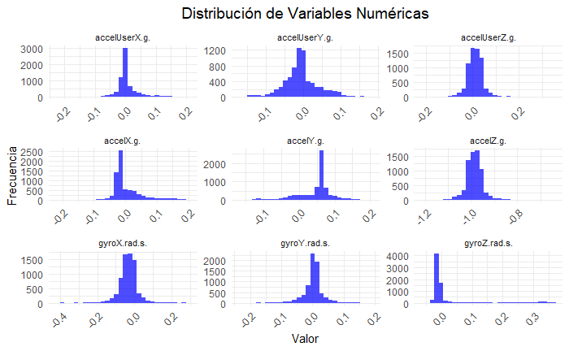

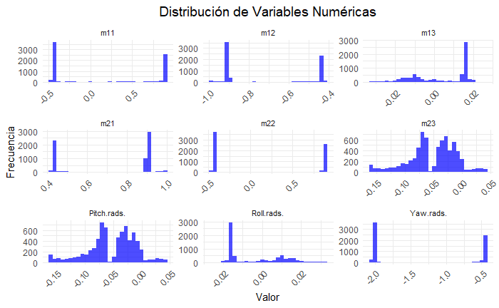

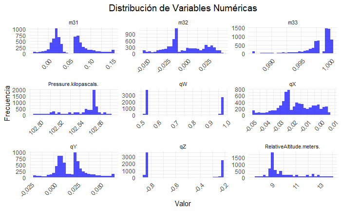

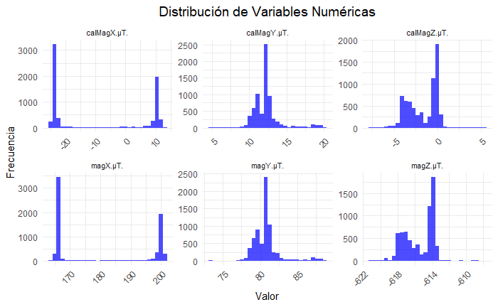

```r
# Instalar y cargar tidyr si es necesario
if (!requireNamespace("tidyr", quietly = TRUE)) {
  install.packages("tidyr")
}
library(tidyr)

# Visualización: Histogramas de Variables Numéricas
# Visualización: Histogramas de Variables Numéricas
# Dividir las variables en grupos de 9
variable_groups <- split(names(num_data), ceiling(seq_along(names(num_data)) / 9))

for (group in variable_groups) {
  # Filtrar las variables del grupo actual
  group_data <- num_data %>% select(all_of(group))

  # Convertir a formato largo
  group_data_long <- group_data %>%
    pivot_longer(cols = everything(), names_to = "Variable", values_to = "Valor")

  # Crear los gráficos
  print(
    ggplot(group_data_long, aes(x = Valor)) +
      geom_histogram(bins = 30, fill = "blue", alpha = 0.7) +
      facet_wrap(~ Variable, scales = "free", ncol = 3) +
      theme_minimal() +
      theme(
        strip.text = element_text(size = 8),
        axis.text.x = element_text(angle = 45, hjust = 1),
        plot.title = element_text(size = 14, hjust = 0.5)
      ) +
      labs(title = "Distribución de Variables Numéricas",
           x = "Valor",
           y = "Frecuencia")
  )
}
```

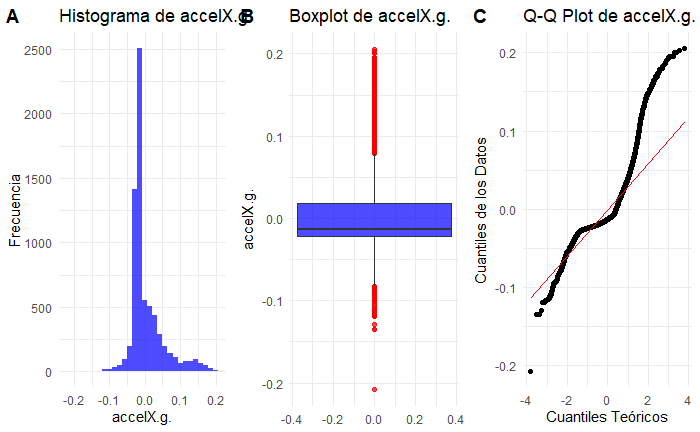

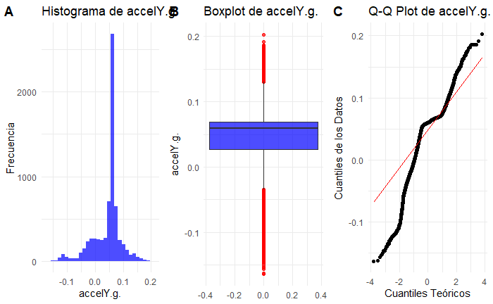

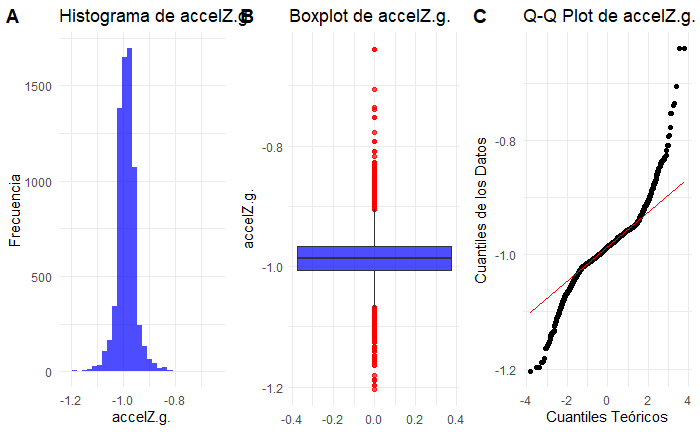

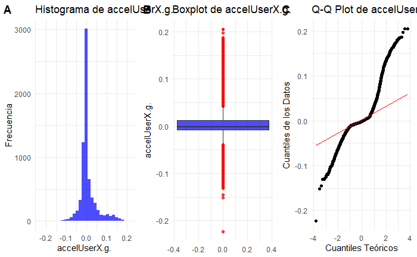

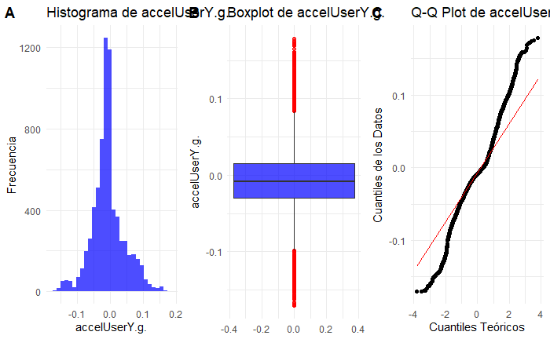

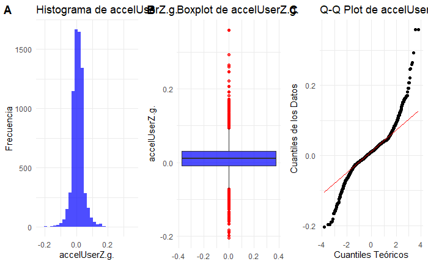

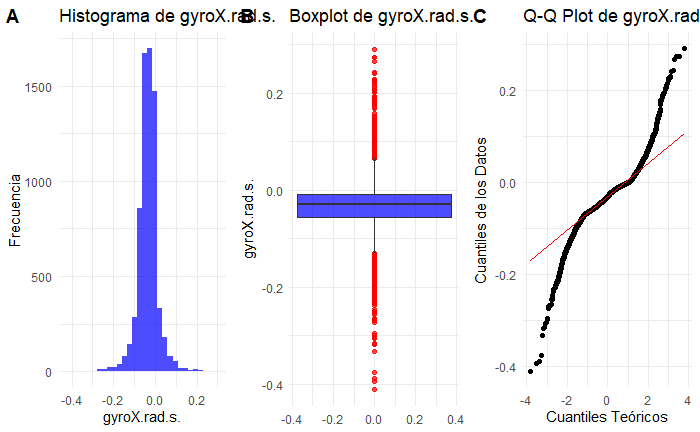

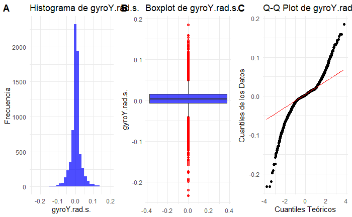

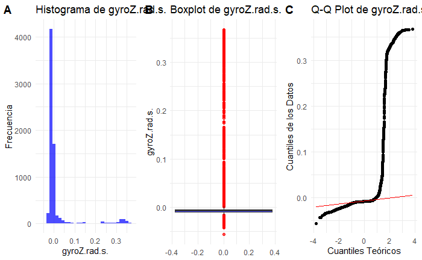

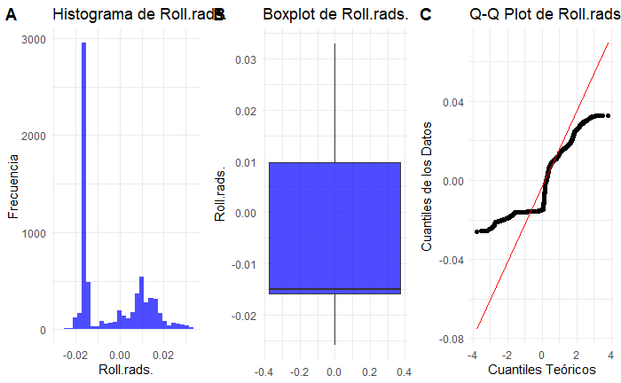

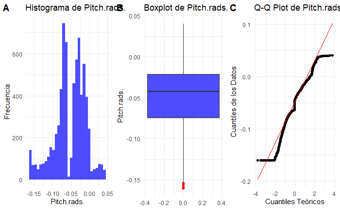

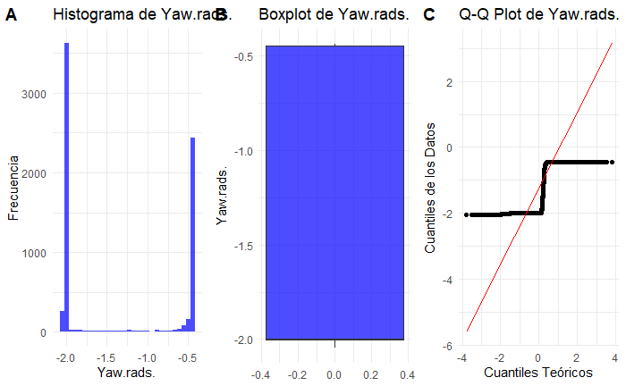

[21 more figures not shown]

```r
# Cargar librerías necesarias
if (!requireNamespace("tidyverse", quietly = TRUE)) install.packages("tidyverse")
if (!requireNamespace("cowplot", quietly = TRUE)) install.packages("cowplot")
library(tidyverse)
library(cowplot)

# Eliminar valores NA en num_data
num_data_clean <- num_data %>% drop_na()

# Confirmar que hay variables numéricas
if (ncol(num_data_clean) > 0) {
  # Iterar sobre las variables numéricas
  for (var in names(num_data_clean)) {
    # Crear histogramas
    hist_plot <- ggplot(num_data_clean, aes(x = !!sym(var))) +
      geom_histogram(bins = 30, fill = "blue", alpha = 0.7) +
      theme_minimal() +
      labs(title = paste("Histograma de", var), x = var, y = "Frecuencia")

    # Crear boxplots
    box_plot <- ggplot(num_data_clean, aes(y = !!sym(var))) +
      geom_boxplot(fill = "blue", alpha = 0.7, outlier.color = "red") +
      theme_minimal() +
      labs(title = paste("Boxplot de", var), y = var)

    # Crear Q-Q plots
    qq_plot <- ggplot(num_data_clean, aes(sample = !!sym(var))) +
      stat_qq() +
      stat_qq_line(color = "red") +
      theme_minimal() +
      labs(title = paste("Q-Q Plot de", var), x = "Cuantiles Teóricos", y = "Cuantiles de los Datos")

    # Mostrar los gráficos en una cuadrícula
    print(plot_grid(hist_plot, box_plot, qq_plot, ncol = 3, labels = c("A", "B", "C")))
  }
} else {
  cat("No hay variables numéricas en el dataset.\n")
}
```

```r
NA
NA
```

## 3.2 Variables Categóricas

Las variables categóricas se analizan para evaluar el balance de las clases, especialmente la variable objetivo.

```r
# Convertir las columnas character restantes en factor
data <- data %>%
  mutate(across(where(is.character), as.factor))

# Seleccionar las variables categóricas
cat_data <- data %>% select(where(is.factor))

# Verificar las estadísticas de variables categóricas
if (ncol(cat_data) > 0) {
  cat("### Estadísticas para Variables Categóricas\n")
  print(sapply(cat_data, table))
}
```

```
### Estadísticas para Variables Categóricas
$ActivityType

Coche Urbano 250
            7033

$ActivityConfidence

High  Low
6574  459
```

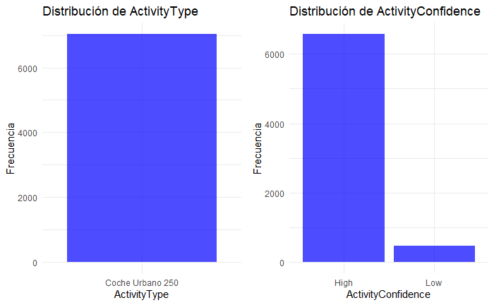

```r
# Gráficos de barras para cada variable categórica
# Crear una lista para almacenar los gráficos
plot_list <- list()

# Crear gráficos de barras para cada variable categórica y almacenarlos en la lista
for (var in names(cat_data)) {
  p <- ggplot(cat_data, aes_string(x = var)) +
    geom_bar(fill = "blue", alpha = 0.7) +
    theme_minimal() +
    labs(title = paste("Distribución de", var),
         x = var,
         y = "Frecuencia") +
    theme(axis.text.x = element_text(angle = 0, hjust = 0.5)) # Categorías horizontales

  # Agregar el gráfico a la lista
  plot_list[[var]] <- p
}
# Combinar todos los gráficos en una sola hoja
grid.arrange(grobs = plot_list, ncol = 2) # Ajusta ncol para cambiar las columnas
```

# 4. Análisis de Valores Faltantes y Outliers

## 4.1 Detección de Valores faltantes

Identificar valores faltantes es crucial porque pueden afectar el rendimiento del modelo predictivo. Este paso ayuda a decidir estrategias para imputar o manejar estos valores.

```r
cat("### Análisis de Valores Faltantes\n")
```

```
### Análisis de Valores Faltantes
```

```r
# Resumen de valores faltantes por columna
print(sapply(data, function(x) sum(is.na(x))))
```

```
               accelX.g.                accelY.g.                accelZ.g.            accelUserX.g.            accelUserY.g.            accelUserZ.g.             gyroX.rad.s.             gyroY.rad.s.
                       0                        0                        0                        0                        0                        0                        0                        0
            gyroZ.rad.s.               Roll.rads.              Pitch.rads.                Yaw.rads.                      m11                      m12                      m13                      m21
                       0                        0                        0                        0                        0                        0                        0                        0
                     m22                      m23                      m31                      m32                      m33                       qX                       qY                       qZ
                       0                        0                        0                        0                        0                        0                        0                        0
                      qW             ActivityType       ActivityConfidence    Pressure.kilopascals. RelativeAltitude.meters.                 magX.µT.                 magY.µT.                 magZ.µT.
                       0                        0                        0                        0                        0                        0                        0                        0
             calMagX.µT.              calMagY.µT.              calMagZ.µT.
                       0                        0                        0
```

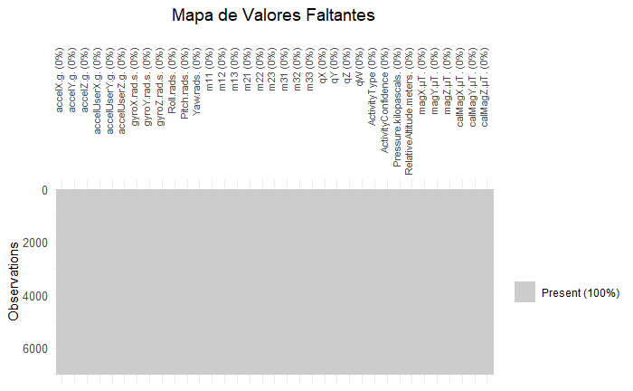

```r
# Visualización de valores faltantes mejorada
vis_miss(data) +
  ggtitle("Mapa de Valores Faltantes") +
  theme_minimal() +
  theme(
    axis.text.x = element_text(angle = 90, hjust = 1, size = 8), # Ajuste de las etiquetas del eje X
    axis.text.y = element_text(size = 10),                       # Ajuste de las etiquetas del eje Y
    plot.title = element_text(hjust = 0.5, size = 14)            # Centrar y ajustar tamaño del título
  )
```

```r
NA
NA
```

El resultado muestra que no hay datos nulos en el dataset.

## 4.2 Detección de Outliers Univariantes

Usaremos el rango intercuartílico (IQR) para identificar outliers y calcular el porcentaje de valores extremos en cada variable numérica.

```r
if (ncol(num_data) > 0) {
  cat("### Análisis de Outliers\n")

  # Cálculo de outliers por IQR
  outlier_detection <- num_data %>%
    summarise(across(everything(), ~ {
      q1 <- quantile(.x, 0.25, na.rm = TRUE)
      q3 <- quantile(.x, 0.75, na.rm = TRUE)
      iqr <- q3 - q1
      sum(.x < (q1 - 1.5 * iqr) | .x > (q3 + 1.5 * iqr), na.rm = TRUE) / length(.x) * 100
    }))

  # Transponer la tabla
  outlier_detection <- as.data.frame(t(outlier_detection))
  outlier_detection$Variable <- rownames(outlier_detection)
  rownames(outlier_detection) <- NULL

  # Reordenar las columnas
  outlier_detection <- outlier_detection %>%
    select(Variable, `Outliers (%)` = V1) %>%
    arrange(desc(`Outliers (%)`))  # Ordenar de mayor a menor

  # Mostrar la tabla
  print(outlier_detection)
}
```

```
### Análisis de Outliers
```

| Variable | Outliers (%) |
| --- | --- |
| gyroZ.rad.s. | 26.432532 |
| accelUserX.g. | 18.413195 |
| gyroY.rad.s. | 11.389165 |
| accelY.g. | 10.664013 |
| accelX.g. | 9.128395 |
| accelUserY.g. | 8.403242 |
| calMagY.µT. | 8.189962 |
| m33 | 8.090431 |
| magY.µT. | 8.076212 |
| gyroX.rad.s. | 5.602161 |

[output cut: 23 more lines]

**Visualización de Outliers**

Utilizaremos boxplots para visualizar los outliers en cada variable numérica.

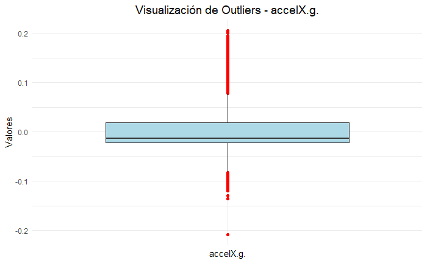

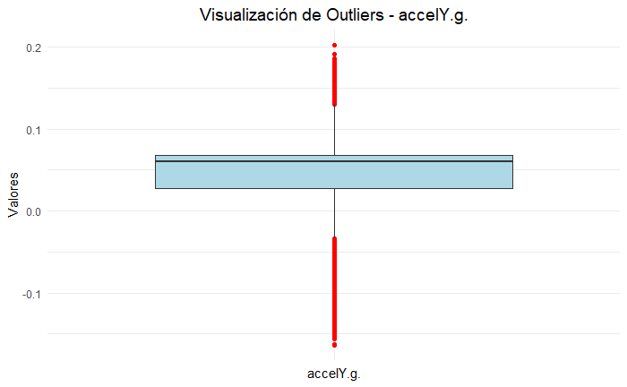

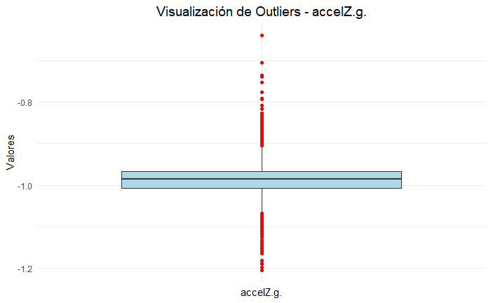

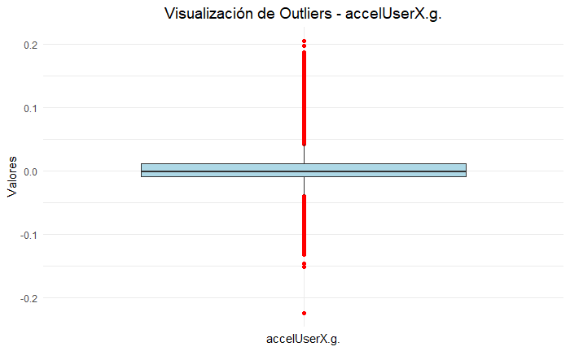

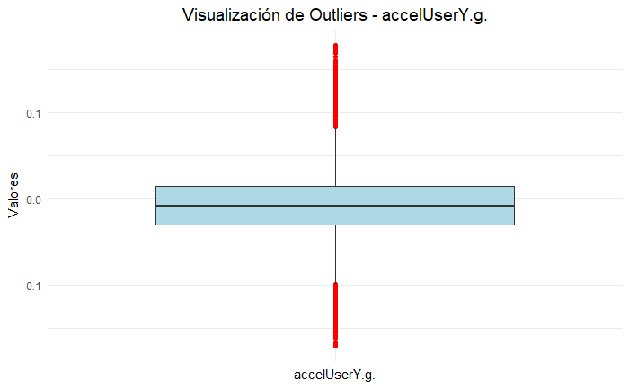

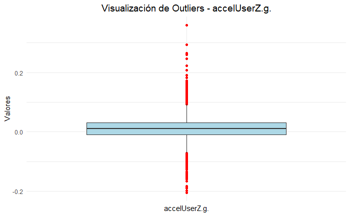

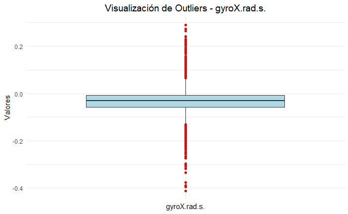

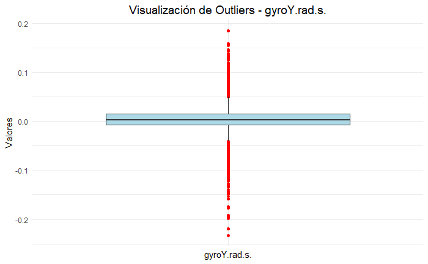

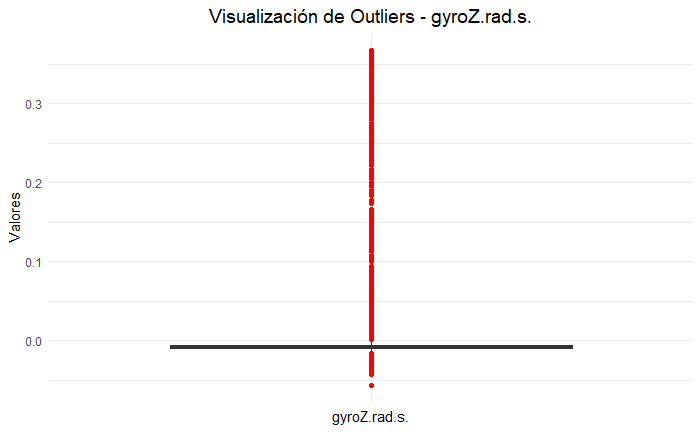

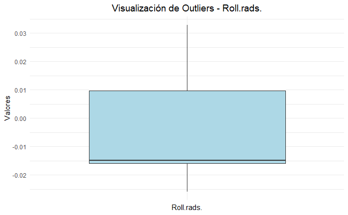

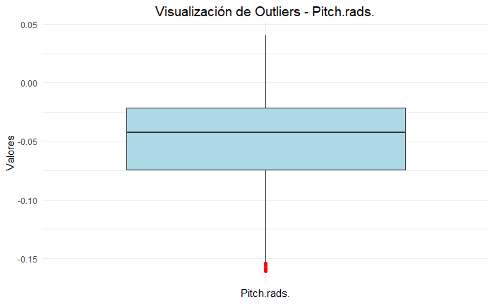

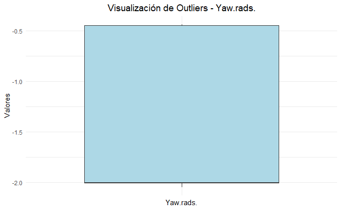

[21 more figures not shown]

```r
if (ncol(num_data) > 0) {
  # Transformar datos a formato largo
  num_data_long <- num_data %>%
    pivot_longer(cols = everything(), names_to = "Variable", values_to = "Valor")

  # Obtener las variables únicas
  unique_variables <- unique(num_data_long$Variable)

  # Crear gráficos individuales en un bucle
  for (var in unique_variables) {
    plot <- ggplot(num_data_long %>% filter(Variable == var), aes(x = Variable, y = Valor)) +
      geom_boxplot(outlier.colour = "red", outlier.size = 1.5, fill = "lightblue") +
      theme_minimal() +
      labs(
        title = paste("Visualización de Outliers -", var),
        x = var,
        y = "Valores"
      ) +
      theme(
        plot.title = element_text(size = 14, hjust = 0.5),
        axis.text.x = element_blank(),
        axis.ticks.x = element_blank()
      )

    # Usar print() explícito para mostrar cada gráfico
    print(plot)
  }
} else {
  cat("No hay variables numéricas en el dataset.\n")
}
```

```r
NA
NA
```

En el análisis univariado, se identificaron variables con un porcentaje significativo de outliers (>10%), lo que puede tener un impacto considerable en el análisis y los resultados si no se abordan adecuadamente. Las variables más relevantes son:

- **gyroY.rad.s. (11,38%) y accelY.g. (10,66%)**
- **gyroZ.rad.s. (26,43) y accelUserX.g. (18,41%)**

Estas variables son esenciales para comprender el sistema de transporte, incluyendo aspectos como posición, estabilidad, y precisión de los sensores. La aplicación de transformaciones adecuadas garantizará una mejor calidad de los datos y robustez en el análisis.

## 4.3 Multivariate Outliers

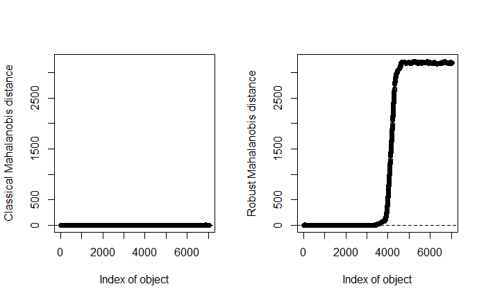

```r
# Cargar la librería
# Crear una copia del dataset original para trabajar
data_analysis <- data

# Seleccionar las variables continuas con mayor porcentaje de outliers (>10%), excluyendo las mencionadas
selected_vars <- data_analysis %>%
  select(gyroZ.rad.s., gyroY.rad.s., Yaw.rads., qZ, accelUserX.g.)  # Incluir variables relevantes

# Calcular las distancias de Mahalanobis (clásica y robusta)
res.out <- Moutlier(selected_vars, quantile = 0.9999)
```

```r
# Inspeccionar resultados
str(res.out)
```

```
List of 3
 $ md    : num [1:7033] 1.25 1.23 1.23 1.23 1.27 ...
 $ rd    : num [1:7033] 3.56 3.46 3.39 3.39 3.34 ...
 $ cutoff: num 5.07
```

```r
# Visualizar outliers multivariantes
par(mfrow = c(1, 1)) # Una sola ventana de gráfico
plot(res.out$md, res.out$rd,
     xlab = "Mahalanobis Clásica",
     ylab = "Mahalanobis Robusta",
     main = "Outliers Multivariantes con Distancias de Mahalanobis")
abline(h = res.out$cutoff, col = "red") # Umbral robusto
```

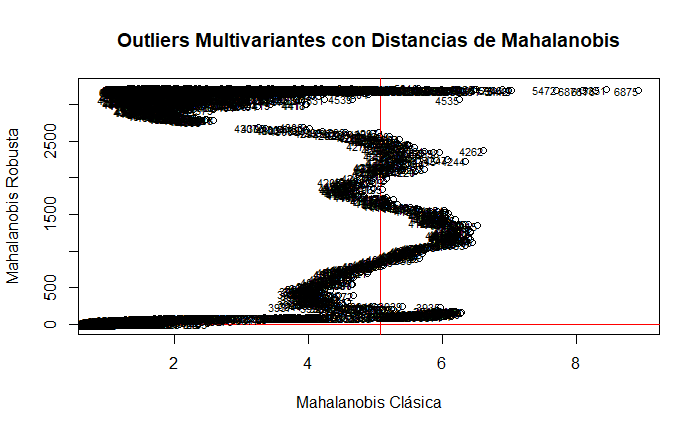

```r
abline(v = res.out$cutoff, col = "red") # Umbral clásico
text(res.out$md, res.out$rd, labels = rownames(data_analysis), adj = 1, cex = 0.7)
```

```r
# Identificar observaciones que son outliers multivariantes
outlier_indices <- which((res.out$md > res.out$cutoff) & (res.out$rd > res.out$cutoff))
cat("Observaciones outliers multivariantes:\n")
```

```
Observaciones outliers multivariantes:
```

```r
print(outlier_indices)
```

```
  [1] 3855 3857 3858 3859 3860 3861 3862 3863 3864 3865 3866 3867 3868 3869 3870 3871 3872 3873 3874 3875 3876 3877 3878 3879 3880 3881 3882 3883 3884 3885 3886 3887 3889 3890 3891 3893 3894 3895 3896 3897 3898 3899 3900
 [44] 3901 3902 3903 3904 3905 3906 3907 3908 3909 3910 3911 3912 3913 3914 3915 3916 3917 3918 3921 3922 3935 3939 4042 4044 4047 4048 4049 4050 4051 4052 4053 4054 4055 4056 4057 4058 4059 4060 4061 4062 4063 4064 4065
 [87] 4066 4067 4068 4069 4070 4071 4072 4073 4074 4075 4076 4077 4078 4079 4080 4081 4082 4083 4084 4085 4086 4087 4088 4089 4090 4091 4092 4093 4094 4095 4096 4097 4098 4099 4100 4101 4102 4103 4104 4105 4106 4107 4108
[130] 4109 4110 4111 4112 4113 4114 4115 4116 4117 4118 4119 4120 4121 4122 4123 4124 4125 4126 4127 4128 4129 4130 4131 4132 4133 4134 4135 4136 4137 4138 4139 4140 4141 4142 4143 4144 4145 4146 4147 4148 4149 4150 4151
[173] 4152 4153 4154 4155 4156 4157 4158 4159 4160 4161 4162 4163 4164 4165 4166 4167 4168 4170 4171 4172 4175 4176 4178 4179 4195 4209 4212 4215 4216 4217 4220 4221 4223 4224 4225 4226 4227 4228 4229 4230 4234 4235 4236
[216] 4237 4238 4239 4240 4241 4242 4243 4244 4245 4246 4247 4248 4249 4250 4251 4252 4253 4254 4255 4256 4257 4258 4259 4260 4261 4262 4263 4264 4265 4266 4267 4268 4269 4271 4272 4273 4274 4275 4276 4277 4278 4279 4283
[259] 4284 4290 4535 5310 5324 5325 5326 5327 5329 5346 5349 5351 5353 5356 5358 5415 5416 5420 5429 5441 5442 5443 5448 5449 5450 5456 5458 5470 5472 5473 5475 5491 5511 5520 5562 5584 5728 5743 5805 5806 5814 5815 5842
[302] 5959 5977 5980 5984 6152 6155 6157 6176 6178 6856 6864 6875 6876 6888 6893 6894 6928 6962 6967 6970 6974
```

```r
# Crear un nuevo dataset con la columna de outliers sin afectar el original
data_with_outliers <- data_analysis %>%
  mutate(outlier_multivar = ifelse(row_number() %in% outlier_indices, "Outlier", "No Outlier"))

# Resumen de la nueva variable en el dataset modificado
table(data_with_outliers$outlier_multivar)
```

```
No Outlier    Outlier
      6711        322
```

Para visualizar estos outliers, se generó un gráfico bivariado que muestra las distancias clásicas frente a las robustas. Los puntos fuera de las líneas rojas en el gráfico representan las observaciones más atípicas, las cuales merecen un análisis más detallado.

```r
# Mostrar un resumen de las filas marcadas como outliers
summary(data_with_outliers %>% filter(outlier_multivar == "Outlier"))
```

```
   accelX.g.          accelY.g.          accelZ.g.       accelUserX.g.      accelUserY.g.      accelUserZ.g.        gyroX.rad.s.       gyroY.rad.s.        gyroZ.rad.s.       Roll.rads.         Pitch.rads.
 Min.   :-0.20820   Min.   :-0.15010   Min.   :-1.1886   Min.   :-0.22400   Min.   :-0.16270   Min.   :-0.189600   Min.   :-0.39470   Min.   :-0.233100   Min.   :-0.0566   Min.   :-0.023100   Min.   :-0.04580
 1st Qu.: 0.09788   1st Qu.: 0.00670   1st Qu.:-1.0116   1st Qu.: 0.08772   1st Qu.:-0.01780   1st Qu.:-0.011700   1st Qu.:-0.07297   1st Qu.:-0.048400   1st Qu.: 0.1462   1st Qu.: 0.004200   1st Qu.:-0.02728
 Median : 0.12590   Median : 0.07920   Median :-0.9863   Median : 0.11505   Median : 0.05500   Median : 0.013400   Median :-0.03470   Median :-0.020900   Median : 0.3167   Median : 0.015050   Median :-0.02530
 Mean   : 0.10885   Mean   : 0.06303   Mean   :-0.9902   Mean   : 0.09933   Mean   : 0.03908   Mean   : 0.009478   Mean   :-0.03880   Mean   :-0.022103   Mean   : 0.2316   Mean   : 0.009811   Mean   :-0.02393
 3rd Qu.: 0.14770   3rd Qu.: 0.10450   3rd Qu.:-0.9640   3rd Qu.: 0.13715   3rd Qu.: 0.08223   3rd Qu.: 0.035550   3rd Qu.:-0.00390   3rd Qu.: 0.003825   3rd Qu.: 0.3277   3rd Qu.: 0.019600   3rd Qu.:-0.02070
 Max.   : 0.19570   Max.   : 0.19190   Max.   :-0.7927   Max.   : 0.20490   Max.   : 0.17230   Max.   : 0.207000   Max.   : 0.27310   Max.   : 0.184900   Max.   : 0.3665   Max.   : 0.029900   Max.   :-0.00320
   Yaw.rads.            m11               m12               m13                 m21              m22               m23                m31               m32                  m33               qX
 Min.   :-2.0138   Min.   :-0.4289   Min.   :-0.9987   Min.   :-0.029900   Min.   :0.4264   Min.   :-0.4286   Min.   :-0.04570   Min.   :0.00090   Min.   :-3.670e-02   Min.   :0.9990   Min.   :-0.022400
 1st Qu.:-1.4623   1st Qu.: 0.1077   1st Qu.:-0.9488   1st Qu.:-0.019600   1st Qu.:0.6926   1st Qu.: 0.1083   1st Qu.:-0.02728   1st Qu.:0.01070   1st Qu.:-2.310e-02   1st Qu.:0.9994   1st Qu.:-0.013275
 Median :-1.1965   Median : 0.3654   Median :-0.9115   Median :-0.015050   Median :0.9116   Median : 0.3655   Median :-0.02530   Median :0.02015   Median :-4.000e-04   Median :0.9996   Median :-0.005950
 Mean   :-1.1696   Mean   : 0.3436   Mean   :-0.8024   Mean   :-0.009807   Mean   :0.8023   Mean   : 0.3437   Mean   :-0.02393   Mean   :0.01898   Mean   :-7.671e-05   Mean   :0.9995   Mean   :-0.006366
 3rd Qu.:-0.7654   3rd Qu.: 0.7214   3rd Qu.:-0.6923   3rd Qu.:-0.004175   3rd Qu.:0.9484   3rd Qu.: 0.7208   3rd Qu.:-0.02070   3rd Qu.:0.02788   3rd Qu.: 2.250e-02   3rd Qu.:0.9996   3rd Qu.: 0.000775
 Max.   :-0.4407   Max.   : 0.9043   Max.   :-0.4268   Max.   : 0.023100   Max.   :0.9987   Max.   : 0.9041   Max.   :-0.00320   Max.   :0.03250   Max.   : 4.170e-02   Max.   :0.9999   Max.   : 0.004700
       qY                  qZ                qW                   ActivityType ActivityConfidence Pressure.kilopascals. RelativeAltitude.meters.    magX.µT.        magY.µT.        magZ.µT.       calMagX.µT.
 Min.   :-0.005900   Min.   :-0.8452   Min.   :0.5343   Coche Urbano 250:322   High:319           Min.   :102.5         Min.   : 9.549           Min.   :168.0   Min.   :77.81   Min.   :-619.9   Min.   :-21.350
 1st Qu.: 0.006000   1st Qu.:-0.6677   1st Qu.:0.7442                          Low :  3           1st Qu.:102.5         1st Qu.: 9.697           1st Qu.:178.4   1st Qu.:82.53   1st Qu.:-617.2   1st Qu.:-10.616
 Median : 0.011500   Median :-0.5632   Median :0.8262                                             Median :102.5         Median : 9.724           Median :184.8   Median :86.90   Median :-614.5   Median : -4.676
 Mean   : 0.009652   Mean   :-0.5336   Mean   :0.8066                                             Mean   :102.5         Mean   :10.121           Mean   :185.4   Mean   :85.15   Mean   :-615.4   Mean   : -3.866
 3rd Qu.: 0.014200   3rd Qu.:-0.3733   3rd Qu.:0.9275                                             3rd Qu.:102.5         3rd Qu.: 9.729           3rd Qu.:195.6   3rd Qu.:87.87   3rd Qu.:-614.2   3rd Qu.:  6.204
 Max.   : 0.019800   Max.   :-0.2186   Max.   :0.9757                                             Max.   :102.5         Max.   :14.078           Max.   :201.1   Max.   :88.61   Max.   :-609.9   Max.   : 11.849
  calMagY.µT.      calMagZ.µT.      outlier_multivar
 Min.   : 9.241   Min.   :-6.0997   Length:322
 1st Qu.:14.287   1st Qu.:-3.4449   Class :character
 Median :18.362   Median :-0.7415   Mode  :character
 Mean   :16.613   Mean   :-1.6119
 3rd Qu.:19.365   3rd Qu.:-0.4553
 Max.   :19.928   Max.   : 3.4312
```

Los resultados indicaron que **322 observaciones** fueron clasificadas como outliers multivariantes. Estas observaciones sobresalen significativamente en el espacio multivariante, lo que sugiere la presencia de eventos extremos o anomalías en los datos. Este comportamiento podría estar asociado a movimientos inusuales del sistema, errores en la captura de datos o condiciones específicas del entorno.

Para abordar estos resultados, se recomienda aplicar técnicas de **winsorización** para limitar el impacto de los valores extremos sin eliminar las observaciones, preservando así su relevancia potencial.

### Revision Manual

```r
# 1. Definir los índices de los outliers multivariantes (actualizados tras revisión manual)
outlier_indices <- c(1, 44, 87, 130, 173, 216, 259, 302)

# 2. Filtrar las observaciones outliers del dataset original
outlier_data <- data_analysis[outlier_indices, ]
View(outlier_data)  # Abrir la vista interactiva para inspección

# 3. Resumen estadístico de los outliers
summary(outlier_data)
```

[output not shown]

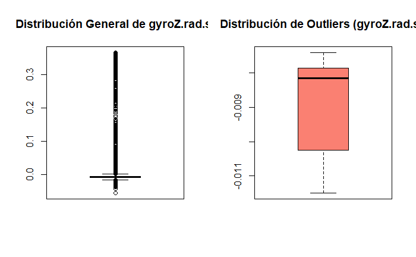

```r
# 4. Comparar distribuciones con el resto del dataset
# Variable gyroZ.rad.s.
par(mfrow = c(1, 2))  # Dividir la pantalla en dos gráficos
boxplot(data_analysis$gyroZ.rad.s., main = "Distribución General de gyroZ.rad.s.", col = "lightblue")
boxplot(outlier_data$gyroZ.rad.s., main = "Distribución de Outliers (gyroZ.rad.s.)", col = "salmon")
```

```r
# 5. Inspeccionar registros adicionales
head(outlier_data[, c("ActivityType", "gyroZ.rad.s.", "gyroY.rad.s.")])
```

|  | ActivityType | gyroZ.rad.s. | gyroY.rad.s. |
| --- | --- | --- | --- |
| 1 | Coche Urbano 250 | -0.0095 | 0.0103 |
| 44 | Coche Urbano 250 | -0.0115 | 0.0136 |
| 87 | Coche Urbano 250 | -0.0074 | 0.0534 |
| 130 | Coche Urbano 250 | -0.0110 | 0.0060 |
| 173 | Coche Urbano 250 | -0.0083 | -0.0004 |
| 216 | Coche Urbano 250 | -0.0078 | -0.0070 |

```r
# 6. Agregar una columna de decisión manual para cada outlier
outlier_data <- outlier_data %>%
  mutate(decision = ifelse(gyroZ.rad.s. > 15 & gyroY.rad.s. > 15, "Conservar", "Revisar"))

# Mostrar dataset con decisiones
View(outlier_data)

# 7. Incorporar las decisiones al dataset original
data_analysis$outlier_review <- "No Outlier"
data_analysis$outlier_review[outlier_indices] <- outlier_data$decision

# 8. Resumen de las decisiones tomadas
table(data_analysis$outlier_review)
```

```
No Outlier    Revisar
      7025          8
```

### Validación Manual de Outliers Multivariantes

#### Observaciones de la Validación Manual

**Verificación de los Valores:**

**Análisis de Contexto:**

- Estas mediciones pueden reflejar eventos reales, como cambios de ritmo, movimientos bruscos o variaciones en el terreno, aunque no se descartan posibles ruidos del sensor.

### Conclusión de la Validación Manual

- No se detectaron errores evidentes en el formato de los datos ni inconsistencias generales en los registros revisados.

### Próximos Pasos

1. **Transformaciones de Datos:**
   - Aplicar **winsorización** a las variables afectadas para limitar el impacto de los valores extremos mientras se conserva la estructura de los datos.
   - Alternativamente, considerar transformaciones logarítmicas para suavizar las distribuciones.
2. **Preparación para el Modelado:**
   - Escalar las variables seleccionadas tras la transformación para uniformar las magnitudes y reducir la influencia de los valores extremos en el entrenamiento del modelo.

# 3. Pruebas de Normalidad

Evaluar si las variables numéricas siguen una distribución normal es un paso clave para seleccionar las técnicas estadísticas y de modelado más adecuadas. Esto permite asegurar que los supuestos subyacentes de ciertos métodos estadísticos, como pruebas paramétricas o modelos lineales, se cumplan correctamente.

**Hipótesis:**

- **Nula (H₀):** Los datos tienen una distribución normal.
- **Alternativa (H₁):** Los datos no tienen una distribución normal.

Se utilizarán pruebas estadísticas, como **Shapiro-Wilk** o **Kolmogorov-Smirnov**, para contrastar estas hipótesis y determinar si los datos pueden considerarse normalmente distribuidos.

```r
summary(num_data)
```

```
   accelX.g.           accelY.g.          accelZ.g.       accelUserX.g.      accelUserY.g.       accelUserZ.g.       gyroX.rad.s.       gyroY.rad.s.        gyroZ.rad.s.        Roll.rads.        Pitch.rads.
 Min.   :-0.208200   Min.   :-0.16410   Min.   :-1.2046   Min.   :-0.22400   Min.   :-0.170800   Min.   :-0.20490   Min.   :-0.41190   Min.   :-0.233100   Min.   :-0.05660   Min.   :-0.02590   Min.   :-0.16090
 1st Qu.:-0.021600   1st Qu.: 0.02740   1st Qu.:-1.0068   1st Qu.:-0.00830   1st Qu.:-0.030300   1st Qu.:-0.00950   1st Qu.:-0.05690   1st Qu.:-0.006900   1st Qu.:-0.00970   1st Qu.:-0.01590   1st Qu.:-0.07460
 Median :-0.013000   Median : 0.05980   Median :-0.9860   Median :-0.00130   Median :-0.008300   Median : 0.01060   Median :-0.03040   Median : 0.003300   Median :-0.00810   Median :-0.01490   Median :-0.04250
 Mean   : 0.004222   Mean   : 0.04603   Mean   :-0.9864   Mean   : 0.00803   Mean   :-0.005504   Mean   : 0.01136   Mean   :-0.03226   Mean   : 0.003344   Mean   : 0.01354   Mean   :-0.00387   Mean   :-0.05159
 3rd Qu.: 0.018400   3rd Qu.: 0.06850   3rd Qu.:-0.9661   3rd Qu.: 0.01210   3rd Qu.: 0.015200   3rd Qu.: 0.03170   3rd Qu.:-0.00780   3rd Qu.: 0.015700   3rd Qu.:-0.00530   3rd Qu.: 0.00980   3rd Qu.:-0.02150
 Max.   : 0.205500   Max.   : 0.20270   Max.   :-0.6396   Max.   : 0.20490   Max.   : 0.178400   Max.   : 0.35930   Max.   : 0.29060   Max.   : 0.184900   Max.   : 0.36750   Max.   : 0.03290   Max.   : 0.04020
   Yaw.rads.            m11               m12               m13                 m21              m22               m23                m31                m32                 m33               qX
 Min.   :-2.0465   Min.   :-0.4580   Min.   :-0.9997   Min.   :-0.032900   Min.   :0.4245   Min.   :-0.4580   Min.   :-0.16020   Min.   :-0.03130   Min.   :-0.053500   Min.   :0.9869   Min.   :-0.05030
 1st Qu.:-2.0028   1st Qu.:-0.4174   1st Qu.:-0.9086   1st Qu.:-0.009800   1st Qu.:0.4338   1st Qu.:-0.4172   1st Qu.:-0.07450   1st Qu.: 0.01690   1st Qu.:-0.018400   1st Qu.:0.9971   1st Qu.:-0.02680
 Median :-2.0020   Median :-0.4170   Median :-0.9083   Median : 0.014700   Median :0.8999   Median :-0.4156   Median :-0.04250   Median : 0.03180   Median :-0.012300   Median :0.9990   Median :-0.01980
 Mean   :-1.3642   Mean   : 0.1289   Mean   :-0.7253   Mean   : 0.003841   Mean   :0.7231   Mean   : 0.1291   Mean   :-0.05152   Mean   : 0.04854   Mean   :-0.003073   Mean   :0.9977   Mean   :-0.01883
 3rd Qu.:-0.4490   3rd Qu.: 0.9008   3rd Qu.:-0.4342   3rd Qu.: 0.015900   3rd Qu.:0.9060   3rd Qu.: 0.9005   3rd Qu.:-0.02150   3rd Qu.: 0.07430   3rd Qu.: 0.019700   3rd Qu.:0.9996   3rd Qu.:-0.00770
 Max.   :-0.4385   Max.   : 0.9053   Max.   :-0.4247   Max.   : 0.025900   Max.   :0.9997   Max.   : 0.9053   Max.   : 0.04020   Max.   : 0.15240   Max.   : 0.042800   Max.   :1.0000   Max.   : 0.00700
       qY                 qZ                qW         Pressure.kilopascals. RelativeAltitude.meters.    magX.µT.        magY.µT.        magZ.µT.       calMagX.µT.       calMagY.µT.     calMagZ.µT.
 Min.   :-0.02060   Min.   :-0.8538   Min.   :0.5206   Min.   :102.5         Min.   : 7.647           Min.   :164.1   Min.   :73.31   Min.   :-621.3   Min.   :-25.413   Min.   : 4.55   Min.   :-7.5339
 1st Qu.: 0.00690   1st Qu.:-0.8414   1st Qu.:0.5389   1st Qu.:102.5         1st Qu.: 9.158           1st Qu.:166.1   1st Qu.:79.74   1st Qu.:-617.1   1st Qu.:-23.229   1st Qu.:11.19   1st Qu.:-3.2925
 Median : 0.01590   Median :-0.8402   Median :0.5394   Median :102.6         Median : 9.306           Median :166.5   Median :80.75   Median :-614.5   Median :-22.918   Median :12.23   Median :-0.7563
 Mean   : 0.01834   Mean   :-0.5889   Mean   :0.7208   Mean   :102.5         Mean   :10.088           Mean   :180.0   Mean   :80.77   Mean   :-615.4   Mean   : -9.383   Mean   :12.24   Mean   :-1.6437
 3rd Qu.: 0.02710   3rd Qu.:-0.2226   3rd Qu.:0.9748   3rd Qu.:102.6         3rd Qu.:11.003           3rd Qu.:199.6   3rd Qu.:81.05   3rd Qu.:-613.9   3rd Qu.: 10.218   3rd Qu.:12.51   3rd Qu.:-0.1249
 Max.   : 0.06350   Max.   :-0.2175   Max.   :0.9760   Max.   :102.6         Max.   :14.078           Max.   :201.7   Max.   :88.61   Max.   :-608.0   Max.   : 12.616   Max.   :19.93   Max.   : 5.6531
```

```r
# Filtrar variables numéricas excluyendo las indicadas
variables_a_descartar <- c("Lat", "Long", "Speed.m.s.", "TrueHeading",
                           "Alt.m.", "HorizontalAccuracy.m.", "VerticalAccuracy.m.", "Course")

num_data_filtrado <- num_data[, !(names(num_data) %in% variables_a_descartar)]

# Filtrar solo las columnas numéricas que tengan entre 3 y 5000 valores no NA
num_data_filtrado <- num_data_filtrado[, sapply(num_data_filtrado, function(x) {
  num_vals <- sum(!is.na(x))  # Contar valores no nulos
  num_vals >= 3 && num_vals <= 5000
})]

# Verificar si hay variables numéricas restantes después del filtrado
if (ncol(num_data_filtrado) > 0) {
  cat("### Pruebas de Normalidad con Interpretación\n")

  # Crear una lista para almacenar resultados
  normality_interpretation <- list()

  # Iterar por cada columna numérica
  for (variable in names(num_data_filtrado)) {
    # Realizar el test de Shapiro-Wilk
    shapiro_test <- shapiro.test(num_data_filtrado[[variable]])

    # Evaluar el resultado
    if (shapiro_test$p.value > 0.05) {
      interpretation <- paste(
        "La variable", variable,
        "tiene un p-value =", round(shapiro_test$p.value, 4),
        "- Se acepta la hipótesis nula, la muestra tiene una distribución normal (Probablemente Gaussiana).\n"
      )
    } else {
      interpretation <- paste(
        "La variable", variable,
        "tiene un p-value =", round(shapiro_test$p.value, 4),
        "- Se rechaza la hipótesis nula, la muestra no tiene una distribución normal (Probablemente no Gaussiana).\n"
      )
    }

    # Agregar resultado a la lista
    normality_interpretation[[variable]] <- interpretation
  }

  # Imprimir resultados para cada variable
  for (result in normality_interpretation) {
    cat(result)
    cat("------------------------------------------------------------\n")
  }
} else {
  cat("No hay variables numéricas en el dataset después de filtrar.\n")
}
```

```
No hay variables numéricas en el dataset después de filtrar.
```

# **6**. Análisis de Correlaciones

Las correlaciones entre variables numéricas son esenciales para identificar redundancias o relaciones útiles para el modelado.

```r
install.packages("kableExtra")
```

[output not shown]

```r
library(knitr)      # Para formatear tablas
library(kableExtra) # Para mejorar la presentación

# Seleccionar solo variables numéricas relevantes, excluyendo las mencionadas
num_data_filtered <- num_data

# Calcular la matriz de correlación
cor_matrix <- cor(num_data_filtered, use = "complete.obs")

# Redondear para mejor visualización
cor_matrix_rounded <- round(cor_matrix, 2)

# Imprimir la matriz de correlación en la consola
print(cor_matrix_rounded)
```

```
                         accelX.g. accelY.g. accelZ.g. accelUserX.g. accelUserY.g. accelUserZ.g. gyroX.rad.s. gyroY.rad.s. gyroZ.rad.s. Roll.rads. Pitch.rads. Yaw.rads.   m11   m12   m13   m21   m22   m23   m31   m32
accelX.g.                     1.00      0.10     -0.02          0.95          0.37          0.00         0.06        -0.27         0.72       0.53        0.32      0.28  0.30  0.14 -0.53 -0.14  0.30  0.32 -0.35  0.13
accelY.g.                     0.10      1.00      0.14          0.09          0.65          0.11         0.15         0.03         0.07       0.06       -0.45     -0.22 -0.23 -0.23 -0.06  0.23 -0.23 -0.45  0.42 -0.41
accelZ.g.                    -0.02      0.14      1.00         -0.03          0.10          0.99         0.10         0.16         0.01       0.01       -0.05     -0.03 -0.03 -0.04 -0.01  0.04 -0.03 -0.05  0.05 -0.05
accelUserX.g.                 0.95      0.09     -0.03          1.00          0.24         -0.01         0.07        -0.29         0.74       0.25        0.17      0.07  0.09 -0.08 -0.25  0.08  0.09  0.17 -0.20  0.00
accelUserY.g.                 0.37      0.65      0.10          0.24          1.00          0.13         0.15         0.03         0.22       0.55        0.38      0.24  0.24  0.21 -0.55 -0.20  0.24  0.38 -0.40  0.20
accelUserZ.g.                 0.00      0.11      0.99         -0.01          0.13          1.00         0.11         0.15         0.03       0.05        0.02      0.01  0.01  0.00 -0.05  0.00  0.01  0.02 -0.02  0.01
gyroX.rad.s.                  0.06      0.15      0.10          0.07          0.15          0.11         1.00         0.41        -0.02      -0.01        0.00      0.00  0.00  0.00  0.01  0.00  0.00  0.00  0.01 -0.01
gyroY.rad.s.                 -0.27      0.03      0.16         -0.29          0.03          0.15         0.41         1.00        -0.18      -0.04        0.00     -0.04 -0.05  0.00  0.04  0.00 -0.05  0.00  0.02 -0.03
gyroZ.rad.s.                  0.72      0.07      0.01          0.74          0.22          0.03        -0.02        -0.18         1.00       0.26        0.17      0.05  0.08 -0.16 -0.26  0.16  0.08  0.17 -0.21  0.00
Roll.rads.                    0.53      0.06      0.01          0.25          0.55          0.05        -0.01        -0.04         0.26       1.00        0.57      0.74  0.74  0.68 -1.00 -0.68  0.74  0.57 -0.59  0.42
Pitch.rads.                   0.32     -0.45     -0.05          0.17          0.38          0.02         0.00         0.00         0.17       0.57        1.00      0.56  0.56  0.53 -0.57 -0.52  0.56  1.00 -0.98  0.73
Yaw.rads.                     0.28     -0.22     -0.03          0.07          0.24          0.01         0.00        -0.04         0.05       0.74        0.56      1.00  1.00  0.98 -0.74 -0.98  1.00  0.56 -0.63  0.74
m11                           0.30     -0.23     -0.03          0.09          0.24          0.01         0.00        -0.05         0.08       0.74        0.56      1.00  1.00  0.97 -0.73 -0.97  1.00  0.56 -0.63  0.74
m12                           0.14     -0.23     -0.04         -0.08          0.21          0.00         0.00         0.00        -0.16       0.68        0.53      0.98  0.97  1.00 -0.68 -1.00  0.97  0.53 -0.59  0.73
m13                          -0.53     -0.06     -0.01         -0.25         -0.55         -0.05         0.01         0.04        -0.26      -1.00       -0.57     -0.74 -0.73 -0.68  1.00  0.68 -0.73 -0.57  0.58 -0.42
m21                          -0.14      0.23      0.04          0.08         -0.20          0.00         0.00         0.00         0.16      -0.68       -0.52     -0.98 -0.97 -1.00  0.68  1.00 -0.97 -0.52  0.58 -0.73
m22                           0.30     -0.23     -0.03          0.09          0.24          0.01         0.00        -0.05         0.08       0.74        0.56      1.00  1.00  0.97 -0.73 -0.97  1.00  0.56 -0.63  0.74
m23                           0.32     -0.45     -0.05          0.17          0.38          0.02         0.00         0.00         0.17       0.57        1.00      0.56  0.56  0.53 -0.57 -0.52  0.56  1.00 -0.98  0.73
m31                          -0.35      0.42      0.05         -0.20         -0.40         -0.02         0.01         0.02        -0.21      -0.59       -0.98     -0.63 -0.63 -0.59  0.58  0.58 -0.63 -0.98  1.00 -0.81
m32                           0.13     -0.41     -0.05          0.00          0.20          0.01        -0.01        -0.03         0.00       0.42        0.73      0.74  0.74  0.73 -0.42 -0.73  0.74  0.73 -0.81  1.00
m33                           0.31     -0.36     -0.04          0.17          0.40          0.03         0.00        -0.03         0.18       0.53        0.91      0.56  0.56  0.52 -0.53 -0.51  0.56  0.91 -0.91  0.75
qX                            0.43     -0.34     -0.04          0.26          0.47          0.03         0.00        -0.01         0.27       0.68        0.97      0.52  0.52  0.47 -0.68 -0.46  0.52  0.97 -0.93  0.57
qY                           -0.25      0.50      0.06         -0.13         -0.30         -0.01         0.01         0.01        -0.14      -0.44       -0.96     -0.57 -0.57 -0.55  0.44  0.54 -0.57 -0.96  0.98 -0.86
qZ                            0.27     -0.23     -0.03          0.05          0.23          0.01         0.00        -0.04         0.03       0.73        0.55      1.00  1.00  0.98 -0.73 -0.98  1.00  0.55 -0.62  0.74
qW                            0.32     -0.22     -0.03          0.10          0.24          0.01         0.00        -0.05         0.10       0.74        0.56      1.00  1.00  0.96 -0.74 -0.96  1.00  0.56 -0.63  0.74
```

[output cut: 37 more lines]

```r
# Alternativamente, generar una tabla con kable si prefieres una salida más ordenada
library(knitr)
kable(cor_matrix_rounded, caption = "Tabla de Correlaciones (Excluyendo Variables No Relevantes)")
```

Tabla de Correlaciones (Excluyendo Variables No Relevantes)

|  | accelX.g. | accelY.g. | accelZ.g. | accelUserX.g. | accelUserY.g. | accelUserZ.g. | gyroX.rad.s. | gyroY.rad.s. | gyroZ.rad.s. | Roll.rads. | Pitch.rads. | Yaw.rads. | m11 | m12 | m13 | m21 | m22 | m23 | m31 | m32 | m33 | qX | qY | qZ | qW | Pressure.kilopascals. | RelativeAltitude.meters. | magX.µT. | magY.µT. | … |
| --- | --- | --- | --- | --- | --- | --- | --- | --- | --- | --- | --- | --- | --- | --- | --- | --- | --- | --- | --- | --- | --- | --- | --- | --- | --- | --- | --- | --- | --- | --- |
| accelX.g. | 1.00 | 0.10 | -0.02 | 0.95 | 0.37 | 0.00 | 0.06 | -0.27 | 0.72 | 0.53 | 0.32 | 0.28 | 0.30 | 0.14 | -0.53 | -0.14 | 0.30 | 0.32 | -0.35 | 0.13 | 0.31 | 0.43 | -0.25 | 0.27 | 0.32 | -0.17 | 0.17 | 0.30 | 0.48 | … |
| accelY.g. | 0.10 | 1.00 | 0.14 | 0.09 | 0.65 | 0.11 | 0.15 | 0.03 | 0.07 | 0.06 | -0.45 | -0.22 | -0.23 | -0.23 | -0.06 | 0.23 | -0.23 | -0.45 | 0.42 | -0.41 | -0.36 | -0.34 | 0.50 | -0.23 | -0.22 | 0.07 | -0.07 | -0.20 | 0.07 | … |
| accelZ.g. | -0.02 | 0.14 | 1.00 | -0.03 | 0.10 | 0.99 | 0.10 | 0.16 | 0.01 | 0.01 | -0.05 | -0.03 | -0.03 | -0.04 | -0.01 | 0.04 | -0.03 | -0.05 | 0.05 | -0.05 | -0.04 | -0.04 | 0.06 | -0.03 | -0.03 | 0.01 | -0.01 | -0.03 | 0.03 | … |
| accelUserX.g. | 0.95 | 0.09 | -0.03 | 1.00 | 0.24 | -0.01 | 0.07 | -0.29 | 0.74 | 0.25 | 0.17 | 0.07 | 0.09 | -0.08 | -0.25 | 0.08 | 0.09 | 0.17 | -0.20 | 0.00 | 0.17 | 0.26 | -0.13 | 0.05 | 0.10 | 0.05 | -0.05 | 0.08 | 0.57 | … |
| accelUserY.g. | 0.37 | 0.65 | 0.10 | 0.24 | 1.00 | 0.13 | 0.15 | 0.03 | 0.22 | 0.55 | 0.38 | 0.24 | 0.24 | 0.21 | -0.55 | -0.20 | 0.24 | 0.38 | -0.40 | 0.20 | 0.40 | 0.47 | -0.30 | 0.23 | 0.24 | -0.35 | 0.35 | 0.25 | 0.06 | … |
| accelUserZ.g. | 0.00 | 0.11 | 0.99 | -0.01 | 0.13 | 1.00 | 0.11 | 0.15 | 0.03 | 0.05 | 0.02 | 0.01 | 0.01 | 0.00 | -0.05 | 0.00 | 0.01 | 0.02 | -0.02 | 0.01 | 0.03 | 0.03 | -0.01 | 0.01 | 0.01 | -0.03 | 0.03 | 0.01 | 0.02 | … |
| gyroX.rad.s. | 0.06 | 0.15 | 0.10 | 0.07 | 0.15 | 0.11 | 1.00 | 0.41 | -0.02 | -0.01 | 0.00 | 0.00 | 0.00 | 0.00 | 0.01 | 0.00 | 0.00 | 0.00 | 0.01 | -0.01 | 0.00 | 0.00 | 0.01 | 0.00 | 0.00 | 0.00 | 0.00 | 0.00 | -0.01 | … |
| gyroY.rad.s. | -0.27 | 0.03 | 0.16 | -0.29 | 0.03 | 0.15 | 0.41 | 1.00 | -0.18 | -0.04 | 0.00 | -0.04 | -0.05 | 0.00 | 0.04 | 0.00 | -0.05 | 0.00 | 0.02 | -0.03 | -0.03 | -0.01 | 0.01 | -0.04 | -0.05 | 0.02 | -0.02 | -0.05 | -0.13 | … |
| gyroZ.rad.s. | 0.72 | 0.07 | 0.01 | 0.74 | 0.22 | 0.03 | -0.02 | -0.18 | 1.00 | 0.26 | 0.17 | 0.05 | 0.08 | -0.16 | -0.26 | 0.16 | 0.08 | 0.17 | -0.21 | 0.00 | 0.18 | 0.27 | -0.14 | 0.03 | 0.10 | 0.07 | -0.07 | 0.07 | 0.78 | … |
| Roll.rads. | 0.53 | 0.06 | 0.01 | 0.25 | 0.55 | 0.05 | -0.01 | -0.04 | 0.26 | 1.00 | 0.57 | 0.74 | 0.74 | 0.68 | -1.00 | -0.68 | 0.74 | 0.57 | -0.59 | 0.42 | 0.53 | 0.68 | -0.44 | 0.73 | 0.74 | -0.68 | 0.68 | 0.75 | -0.08 | … |
| Pitch.rads. | 0.32 | -0.45 | -0.05 | 0.17 | 0.38 | 0.02 | 0.00 | 0.00 | 0.17 | 0.57 | 1.00 | 0.56 | 0.56 | 0.53 | -0.57 | -0.52 | 0.56 | 1.00 | -0.98 | 0.73 | 0.91 | 0.97 | -0.96 | 0.55 | 0.56 | -0.50 | 0.50 | 0.55 | -0.02 | … |
| Yaw.rads. | 0.28 | -0.22 | -0.03 | 0.07 | 0.24 | 0.01 | 0.00 | -0.04 | 0.05 | 0.74 | 0.56 | 1.00 | 1.00 | 0.98 | -0.74 | -0.98 | 1.00 | 0.56 | -0.63 | 0.74 | 0.56 | 0.52 | -0.57 | 1.00 | 1.00 | -0.83 | 0.83 | 1.00 | -0.37 | … |
| m11 | 0.30 | -0.23 | -0.03 | 0.09 | 0.24 | 0.01 | 0.00 | -0.05 | 0.08 | 0.74 | 0.56 | 1.00 | 1.00 | 0.97 | -0.73 | -0.97 | 1.00 | 0.56 | -0.63 | 0.74 | 0.56 | 0.52 | -0.57 | 1.00 | 1.00 | -0.83 | 0.83 | 1.00 | -0.35 | … |
| m12 | 0.14 | -0.23 | -0.04 | -0.08 | 0.21 | 0.00 | 0.00 | 0.00 | -0.16 | 0.68 | 0.53 | 0.98 | 0.97 | 1.00 | -0.68 | -1.00 | 0.97 | 0.53 | -0.59 | 0.73 | 0.52 | 0.47 | -0.55 | 0.98 | 0.96 | -0.84 | 0.84 | 0.97 | -0.53 | … |
| m13 | -0.53 | -0.06 | -0.01 | -0.25 | -0.55 | -0.05 | 0.01 | 0.04 | -0.26 | -1.00 | -0.57 | -0.74 | -0.73 | -0.68 | 1.00 | 0.68 | -0.73 | -0.57 | 0.58 | -0.42 | -0.53 | -0.68 | 0.44 | -0.73 | -0.74 | 0.68 | -0.68 | -0.75 | 0.08 | … |
| m21 | -0.14 | 0.23 | 0.04 | 0.08 | -0.20 | 0.00 | 0.00 | 0.00 | 0.16 | -0.68 | -0.52 | -0.98 | -0.97 | -1.00 | 0.68 | 1.00 | -0.97 | -0.52 | 0.58 | -0.73 | -0.51 | -0.46 | 0.54 | -0.98 | -0.96 | 0.84 | -0.84 | -0.97 | 0.53 | … |
| m22 | 0.30 | -0.23 | -0.03 | 0.09 | 0.24 | 0.01 | 0.00 | -0.05 | 0.08 | 0.74 | 0.56 | 1.00 | 1.00 | 0.97 | -0.73 | -0.97 | 1.00 | 0.56 | -0.63 | 0.74 | 0.56 | 0.52 | -0.57 | 1.00 | 1.00 | -0.83 | 0.83 | 1.00 | -0.35 | … |
| m23 | 0.32 | -0.45 | -0.05 | 0.17 | 0.38 | 0.02 | 0.00 | 0.00 | 0.17 | 0.57 | 1.00 | 0.56 | 0.56 | 0.53 | -0.57 | -0.52 | 0.56 | 1.00 | -0.98 | 0.73 | 0.91 | 0.97 | -0.96 | 0.55 | 0.56 | -0.50 | 0.50 | 0.55 | -0.02 | … |
| m31 | -0.35 | 0.42 | 0.05 | -0.20 | -0.40 | -0.02 | 0.01 | 0.02 | -0.21 | -0.59 | -0.98 | -0.63 | -0.63 | -0.59 | 0.58 | 0.58 | -0.63 | -0.98 | 1.00 | -0.81 | -0.91 | -0.93 | 0.98 | -0.62 | -0.63 | 0.59 | -0.59 | -0.62 | 0.03 | … |
| m32 | 0.13 | -0.41 | -0.05 | 0.00 | 0.20 | 0.01 | -0.01 | -0.03 | 0.00 | 0.42 | 0.73 | 0.74 | 0.74 | 0.73 | -0.42 | -0.73 | 0.74 | 0.73 | -0.81 | 1.00 | 0.75 | 0.57 | -0.86 | 0.74 | 0.74 | -0.80 | 0.80 | 0.73 | -0.25 | … |
| m33 | 0.31 | -0.36 | -0.04 | 0.17 | 0.40 | 0.03 | 0.00 | -0.03 | 0.18 | 0.53 | 0.91 | 0.56 | 0.56 | 0.52 | -0.53 | -0.51 | 0.56 | 0.91 | -0.91 | 0.75 | 1.00 | 0.86 | -0.90 | 0.55 | 0.56 | -0.58 | 0.58 | 0.55 | -0.06 | … |
| qX | 0.43 | -0.34 | -0.04 | 0.26 | 0.47 | 0.03 | 0.00 | -0.01 | 0.27 | 0.68 | 0.97 | 0.52 | 0.52 | 0.47 | -0.68 | -0.46 | 0.52 | 0.97 | -0.93 | 0.57 | 0.86 | 1.00 | -0.87 | 0.51 | 0.52 | -0.42 | 0.42 | 0.51 | 0.06 | … |
| qY | -0.25 | 0.50 | 0.06 | -0.13 | -0.30 | -0.01 | 0.01 | 0.01 | -0.14 | -0.44 | -0.96 | -0.57 | -0.57 | -0.55 | 0.44 | 0.54 | -0.57 | -0.96 | 0.98 | -0.86 | -0.90 | -0.87 | 1.00 | -0.57 | -0.58 | 0.56 | -0.56 | -0.56 | 0.05 | … |
| qZ | 0.27 | -0.23 | -0.03 | 0.05 | 0.23 | 0.01 | 0.00 | -0.04 | 0.03 | 0.73 | 0.55 | 1.00 | 1.00 | 0.98 | -0.73 | -0.98 | 1.00 | 0.55 | -0.62 | 0.74 | 0.55 | 0.51 | -0.57 | 1.00 | 1.00 | -0.84 | 0.84 | 1.00 | -0.39 | … |
| qW | 0.32 | -0.22 | -0.03 | 0.10 | 0.24 | 0.01 | 0.00 | -0.05 | 0.10 | 0.74 | 0.56 | 1.00 | 1.00 | 0.96 | -0.74 | -0.96 | 1.00 | 0.56 | -0.63 | 0.74 | 0.56 | 0.52 | -0.58 | 1.00 | 1.00 | -0.83 | 0.83 | 1.00 | -0.33 | … |
| Pressure.kilopascals. | -0.17 | 0.07 | 0.01 | 0.05 | -0.35 | -0.03 | 0.00 | 0.02 | 0.07 | -0.68 | -0.50 | -0.83 | -0.83 | -0.84 | 0.68 | 0.84 | -0.83 | -0.50 | 0.59 | -0.80 | -0.58 | -0.42 | 0.56 | -0.84 | -0.83 | 1.00 | -1.00 | -0.84 | 0.38 | … |
| RelativeAltitude.meters. | 0.17 | -0.07 | -0.01 | -0.05 | 0.35 | 0.03 | 0.00 | -0.02 | -0.07 | 0.68 | 0.50 | 0.83 | 0.83 | 0.84 | -0.68 | -0.84 | 0.83 | 0.50 | -0.59 | 0.80 | 0.58 | 0.42 | -0.56 | 0.84 | 0.83 | -1.00 | 1.00 | 0.84 | -0.38 | … |
| magX.µT. | 0.30 | -0.20 | -0.03 | 0.08 | 0.25 | 0.01 | 0.00 | -0.05 | 0.07 | 0.75 | 0.55 | 1.00 | 1.00 | 0.97 | -0.75 | -0.97 | 1.00 | 0.55 | -0.62 | 0.73 | 0.55 | 0.51 | -0.56 | 1.00 | 1.00 | -0.84 | 0.84 | 1.00 | -0.35 | … |
| magY.µT. | 0.48 | 0.07 | 0.03 | 0.57 | 0.06 | 0.02 | -0.01 | -0.13 | 0.78 | -0.08 | -0.02 | -0.37 | -0.35 | -0.53 | 0.08 | 0.53 | -0.35 | -0.02 | 0.03 | -0.25 | -0.06 | 0.06 | 0.05 | -0.39 | -0.33 | 0.38 | -0.38 | -0.35 | 1.00 | … |
| magZ.µT. | -0.12 | 0.25 | 0.04 | 0.06 | -0.23 | 0.00 | -0.01 | 0.02 | 0.08 | -0.54 | -0.58 | -0.75 | -0.75 | -0.77 | 0.54 | 0.77 | -0.75 | -0.58 | 0.65 | -0.73 | -0.49 | -0.51 | 0.63 | -0.75 | -0.74 | 0.72 | -0.72 | -0.76 | 0.37 | … |
| calMagX.µT. | 0.30 | -0.20 | -0.03 | 0.08 | 0.25 | 0.01 | 0.00 | -0.05 | 0.07 | 0.75 | 0.55 | 1.00 | 1.00 | 0.97 | -0.75 | -0.97 | 1.00 | 0.55 | -0.62 | 0.73 | 0.55 | 0.51 | -0.56 | 1.00 | 1.00 | -0.84 | 0.84 | 1.00 | -0.35 | … |
| calMagY.µT. | 0.48 | 0.07 | 0.03 | 0.57 | 0.06 | 0.02 | -0.01 | -0.13 | 0.78 | -0.08 | -0.02 | -0.37 | -0.35 | -0.53 | 0.08 | 0.53 | -0.35 | -0.02 | 0.03 | -0.25 | -0.06 | 0.06 | 0.06 | -0.39 | -0.33 | 0.38 | -0.38 | -0.36 | 0.99 | … |
| calMagZ.µT. | -0.12 | 0.25 | 0.04 | 0.06 | -0.24 | 0.00 | -0.01 | 0.02 | 0.08 | -0.55 | -0.59 | -0.75 | -0.75 | -0.77 | 0.55 | 0.77 | -0.75 | -0.59 | 0.65 | -0.74 | -0.49 | -0.52 | 0.63 | -0.76 | -0.74 | 0.73 | -0.73 | -0.77 | 0.36 | … |

```r
NA
```

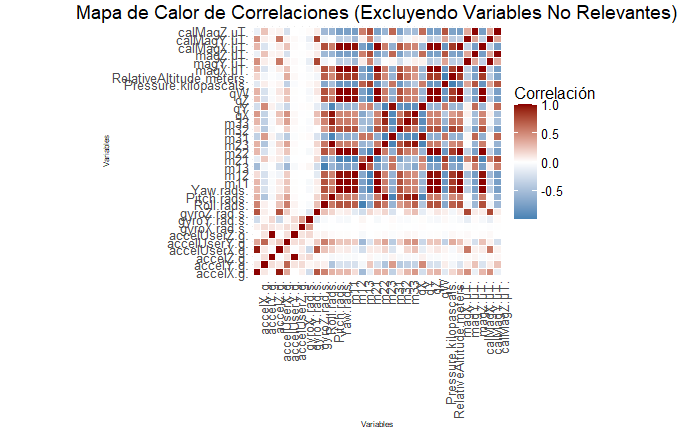

```r
library(ggplot2)
library(reshape2)

# Convertir la matriz en formato largo
corr_melted <- melt(cor_matrix)

# Crear el heatmap
ggplot(corr_melted, aes(x = Var1, y = Var2, fill = value)) +
  geom_tile(color = "white") +
  scale_fill_gradient2(low = "steelblue", high = "darkred", mid = "white", midpoint = 0, name = "Correlación") +
  theme_minimal(base_size = 6) +  # Aumentar el tamaño del texto
  theme(
    axis.text.x = element_text(angle = 90, hjust = 1, size = 10),
    axis.text.y = element_text(size = 10),
    plot.title = element_text(hjust = 0.5, size = 14),
    legend.text = element_text(size = 10),
    legend.title = element_text(size = 12)
  ) +
  labs(
    title = "Mapa de Calor de Correlaciones (Excluyendo Variables No Relevantes)",
    x = "Variables",
    y = "Variables"
  ) +
  coord_fixed()
```

# 7.Descarga del Dataset

```r
write.csv(data, file = "Coche_Urbano_250_limpio.csv", row.names = FALSE)
```

# 8 Conclusiones

El análisis exploratorio del dataset reveló patrones importantes en las variables que describen la actividad de coche urbano 250 HZ. A partir de este análisis, se identificaron **variables clave para la clasificación del modo de transporte**, así como aquellas que pueden ser descartadas debido a su baja aportación informativa o redundancia.

### **Selección de Variables**

#### **Variables Clave para el Modelo**

1. **Aceleración y Giro (Rotación)**
   - **gyroX.rad.s., gyroY.rad.s., gyroZ.rad.s.** → Variables clave para capturar la dinámica de movimiento en los tres ejes. Tienen **alta curtosis y asimetría**, lo que indica la presencia de valores extremos o cambios bruscos en la actividad.
   - **accelX.g., accelY.g., accelZ.g., accelUserX.g., accelUserY.g., accelUserZ.g.** → Capturan la aceleración total y la del usuario. Son cruciales para distinguir patrones de actividad, aunque presentan **distribuciones sesgadas y valores extremos**.
2. **Orientación y Postura**
   - **Pitch.rads., Yaw.rads., Roll.rads.** → Representan la inclinación, guiñada y balanceo.
3. **Altitud y Presión**
   - **RelativeAltitude.meters. y Pressure.kilopascals.** → Son importantes para capturar diferencias en el terreno y la altitud, lo que podría impactar en la detección de cambios de actividad.

#### **Variables a Descartar**

1. **Datos de Localización (Lat, Long, Speed.m.s., TrueHeading, Alt.m.)**
   - Estas variables **no aportan información relevante** para diferenciar entre coche urbano, sino que están más relacionadas con la ubicación geográfica.
   - La velocidad (**Speed.m.s.**) podría ser relevante, pero no de manera directa, ya que puede verse afectada por otros factores externos como pausas o paradas.
2. **Matriz de Orientación (m11, m12, m13, m21, m22, m23, m31, m32, m33)**
   - Presentan **alta correlación entre sí**, lo que sugiere que contienen información redundante. Pueden ser eliminadas sin afectar el rendimiento del modelo.
3. **Datos Magnéticos (magX.µT, magY.µT, magZ.µT y sus versiones calibradas)**
   - Aunque son útiles en algunos contextos, en este caso **no aportan información clara** sobre el modo de transporte y presentan alta redundancia con sus versiones calibradas.
4. **Categorías desconocidas en ActivityType**
   - Se recomienda eliminar la categoría **“Unknown”**, ya que no aporta información relevante y puede sesgar el modelo al introducir ruido en la clasificación.